# automated_lie_detection_package demo

# Introduction

`automated_lie_detection_package` is a Python package for classifying statements as “truthful” or “deceptive” using machine learning models. It provides a simple API for making predictions and can be integrated into various applications.

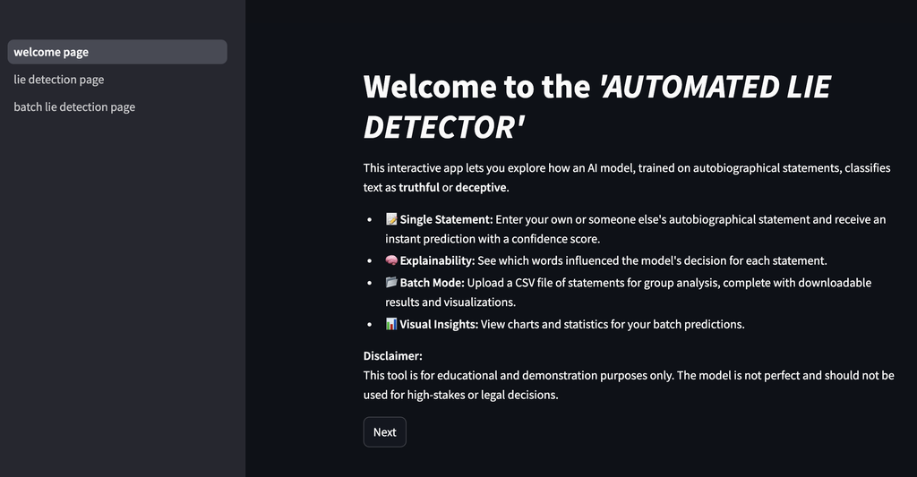

Streamlit App Welcome Page

# Installation

```bash
pip3 install -e src
```

> **Note:**  
> Depending on your environment, you may need to use `pip` instead of `pip3`, and `python` instead of `python3`.  
> For example:

> ```bash
> pip install -e src
> ```

# Model Folder Setup

Before making any predictions, you need to download a pretrained model into a local `models/` directory. By default, the following function downloads a DistilBERT model that has been pretrained to predict lies and truths.

```python
from automated_lie_detection_package import download_model_folder_from_gdrive

download_model_folder_from_gdrive()
```

```
Retrieving folder contents
```

```
Processing file 1BQHmFSnb2vXK5mOE5FGsZutdF1uwybGf config.json
Processing file 1BLONRrK9MXjzjpkOKv-D1ap0WOgzh2jd model.safetensors
Processing file 1BfQqQQ7nQfqH3mS4H58qsBFcCJLutZPh special_tokens_map.json
Processing file 1Bo1gubAWxn1iGvZ6G_oQypVlvH_Ee7Fy tokenizer_config.json
Processing file 1BU1AEtGx7GFvlxo8bJwLuaa-Xo9hgBzr tokenizer.json
Processing file 1BW1RYjeFNeleBmhy9O-m5bMsDK7zmi9d vocab.txt
```

[output not shown]

**Folder structure should look like:**

```
your_project/
├── models/
│   └── [model files here]
├── data/
│   └── exp_data/
├── src/
│   └── automated_lie_detection_package/
│       └── ...
├── run.sh
└── ...
```

# Supported Model Types

The `modelprediction` and `batch_modelprediction` function expects a model folder containing files for a Hugging Face Transformers **sequence classification model** (such as DistilBERT, BERT, RoBERTa, etc.) that can be loaded with `AutoTokenizer.from_pretrained` and `AutoModelForSequenceClassification.from_pretrained`.

**Requirements:**

- All necessary files (e.g., `config.json`, `pytorch_model.bin`, `tokenizer.json`, `vocab.txt`, etc.).
- Model trained or fine-tuned for sequence (text) classification tasks.

**Note:**  
Other model types (e.g., language models for text generation, token classification, etc.) are **not supported** by `modelprediction` and `batch_modelprediction`.

# Usage

## Single Statement Prediction

For a demonstration of using `modelprediction` to classify a statement, see the example below.

```python
from automated_lie_detection_package import modelprediction

input_text = "I swear I am innocent"

# Directly call modelprediction with just the input text
result = modelprediction(input_text)
print(result)
```

[output not shown]

## Batch Prediction

You can run predictions on a CSV or TXT file containing multiple autobiographical statements using the `batch_modelprediction` function.

```python
from automated_lie_detection_package.utility import batch_modelprediction

# For a CSV file (with a column named "statement")
batch_modelprediction(
    input_file="../data/autobiographical_statements.csv",
    output_file="../data/exp_data/batch_predictions.csv",
    column="statement"
)
```

|  | statement | prediction | confidence (%) |
| --- | --- | --- | --- |
| 0 | When I was seven, I accidentally set the kitch... | deceptive | 55.09 |
| 1 | In high school, I built a weather balloon that... | truthful | 61.59 |
| 2 | I once got lost in a foreign city for eight ho... | truthful | 59.39 |
| 3 | As a child, I believed I could talk to animals... | deceptive | 54.64 |
| 4 | One summer, I tried to learn how to skateboard... | truthful | 74.27 |
| 5 | During my gap year, I volunteered at a wildlif... | truthful | 88.20 |
| 6 | I once accidentally joined a wedding processio... | truthful | 56.26 |
| 7 | I spent one winter trying to learn how to knit... | truthful | 69.89 |
| 8 | My first job was at a donut shop where I was t... | truthful | 73.44 |
| 9 | I once mistook a famous actor for a waiter and... | deceptive | 66.13 |
| 10 | Growing up, I had a pet turtle named Mozart wh... | deceptive | 50.92 |
| 11 | I failed my driving test three times because I... | truthful | 82.71 |
| 12 | I once spent two weeks learning sleight-of-han... | truthful | 60.35 |
| 13 | On a dare, I dyed my hair neon green in colleg... | truthful | 56.90 |
| 14 | One time, I accidentally sent a love letter to... | truthful | 76.82 |
| 15 | I got locked inside a museum bathroom overnigh... | truthful | 88.63 |
| 16 | When I was a kid, I wanted to become an astron... | deceptive | 62.69 |
| 17 | I once tried to cook Thanksgiving dinner by my... | deceptive | 56.04 |
| 18 | During a road trip, I accidentally crossed an ... | truthful | 84.91 |
| 19 | I once trained a parrot to say 'Good morning' ... | deceptive | 59.89 |
| 20 | I joined a medieval reenactment group in colle... | truthful | 64.48 |
| 21 | I once got caught in a sudden snowstorm while ... | deceptive | 51.88 |
| 22 | As a teenager, I learned how to juggle and onc... | truthful | 59.83 |
| 23 | I created a short comic series in high school ... | truthful | 63.80 |
| 24 | One summer, I worked as a scare actor at a hau... | truthful | 79.81 |
| 25 | I took a salsa class for a date and ended up b... | truthful | 70.68 |
| 26 | I once spent 48 hours in a library during fina... | truthful | 72.82 |
| 27 | I taught myself Morse code as a hobby during l... | truthful | 61.62 |
| 28 | As a child, I buried a 'time capsule' in our b... | truthful | 66.75 |
| 29 | I once won a hot sauce eating contest and coul... | deceptive | 60.64 |
| 30 | In a college theatre production, I had to step... | truthful | 73.69 |
| 31 | I got chased by a goat while hiking in the cou... | truthful | 73.68 |
| 32 | I once wrote a poem that got published in a na... | truthful | 55.24 |
| 33 | I adopted a dog on impulse after seeing it in ... | deceptive | 56.80 |
| 34 | I learned to unicycle during a summer job at a... | deceptive | 50.71 |
| 35 | I tried to make my own cheese at home and ende... | deceptive | 57.36 |
| 36 | I once fell asleep on a beach and woke up comp... | deceptive | 54.90 |
| 37 | During quarantine, I built a cardboard city in... | truthful | 68.21 |
| 38 | I once mistook a live TV interview for a pre-r... | truthful | 66.48 |
| 39 | I entered a silent retreat for 10 days and acc... | truthful | 88.38 |
| 40 | I learned origami to impress a crush and ended... | truthful | 52.69 |
| 41 | I once accidentally joined a marathon when I w... | truthful | 62.54 |
| 42 | I baked a cake that exploded in the oven becau... | truthful | 58.68 |
| 43 | I once took a midnight swim in a lake and lost... | truthful | 53.82 |
| 44 | My friend and I tried to build a raft out of s... | deceptive | 79.95 |
| 45 | I taught myself to play ukulele just to win a ... | truthful | 53.36 |
| 46 | I ran for student council just to get out of g... | truthful | 52.81 |
| 47 | I got mistaken for a tour guide at a museum an... | truthful | 80.00 |
| 48 | I used to write fan fiction that became more p... | deceptive | 70.62 |
| 49 | I once got stuck in an elevator with a mime wh... | deceptive | 57.86 |

- The function will save the results as a CSV in the `data/exp_data/` folder.
- The output CSV includes the columns: `statement`, `prediction`, and `confidence (%)`.

**Notes:** - For CSV files, make sure the column containing your statements is named correctly (default: `"statement"`). - File type and separator are automatically detected. - Results are saved and can be further visualized in the Streamlit app.

# Streamlit Application Features

## Single Statement Lie Detection

- **Real-time prediction:** Enter any autobiographical statement and receive an instant prediction (truthful or deceptive) with a confidence score.
- **Explainability:** See which words contributed most to the model’s prediction, highlighted in green color.
- **Prediction History:** All your predictions are saved in a session history table, which you can download as a CSV (automatically saved as `data/exp_data/prediction_history.csv`).

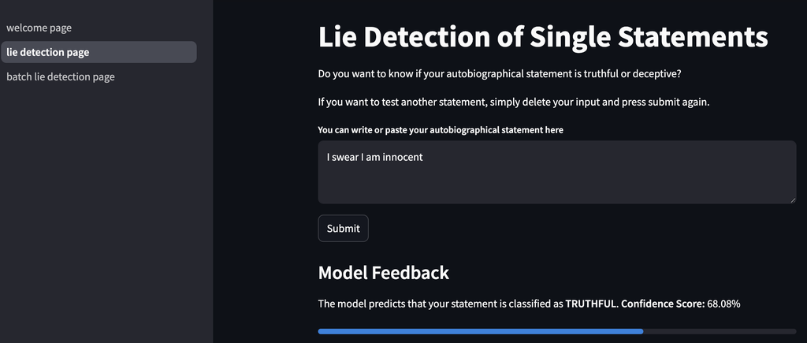

Streamlit App Single Statement Lie Detection

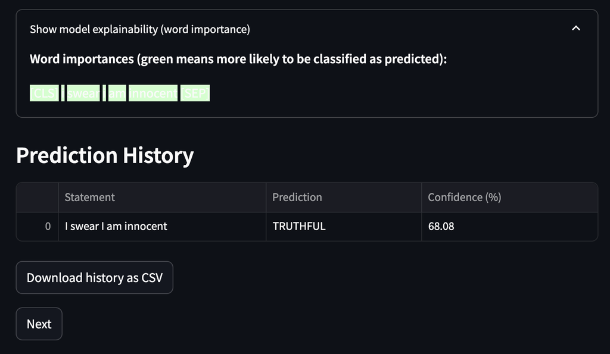

Streamlit App Explainability and History CSV

## Batch Lie Detection

- **CSV Upload or Example File:** Upload your own CSV (with any separator) or use the default example: `data/autobiographical_statements.csv`.
- **Column Selection:** Choose which column contains the statements to analyze.
- **Batch Prediction:** Run predictions on all statements in the file. Results are saved to `data/exp_data/batch_predictions_from_upload.csv`.
- **Download Results:** Download the results as a CSV.
- **Visualizations:**
  - **Prediction Distribution:** See bar and pie charts of truthful vs. deceptive predictions.
  - **Confidence Scores:** View a histogram and boxplot of the model’s confidence scores, including per-class distributions.

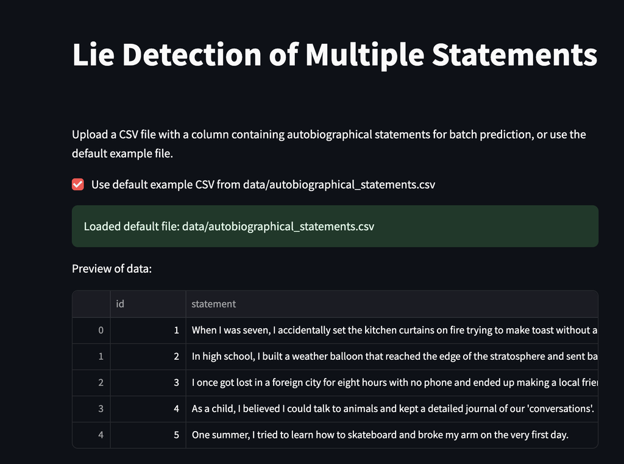

Streamlit App Multiple Statement Lie Detection

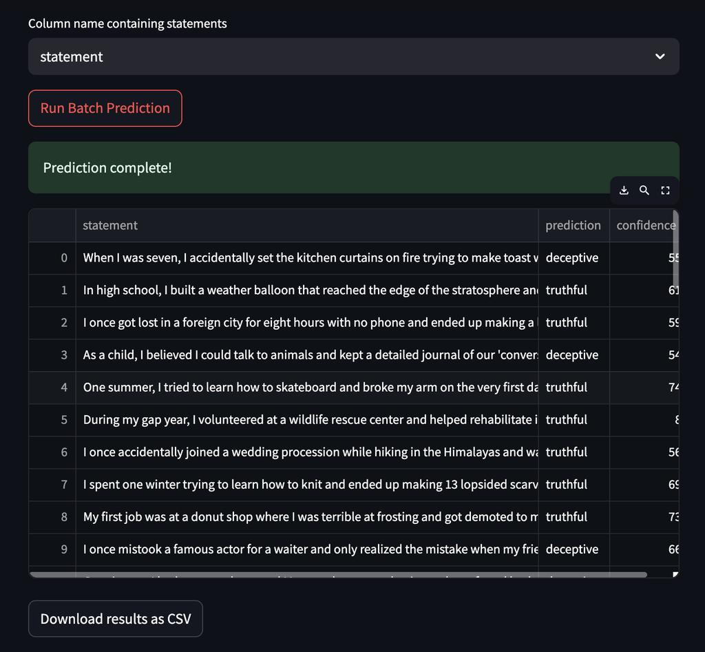

Streamlit App Batch Prediction Results

[figure not shown]

Bar Chart: Prediction Distribution

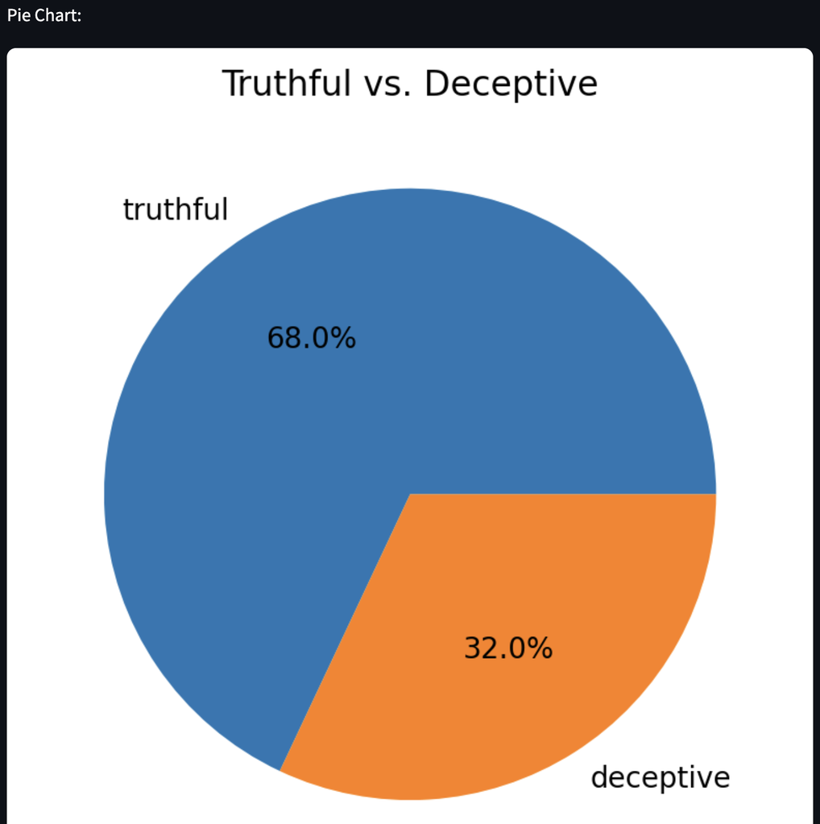

Pie Chart: Prediction Distribution

[figure not shown]

Histogram: Confidence Scores

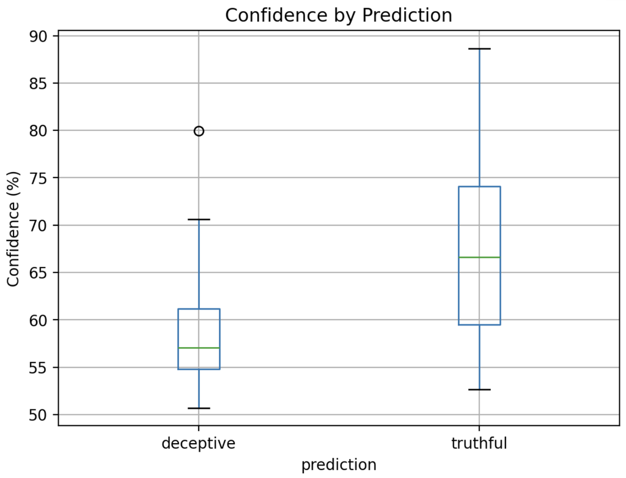

Box Plot: Confidence by Prediction

# Launching the Streamlit App

If you have the run.sh script, first make it executable in your terminal:

```bash
chmod +x run.sh
```

To launch the app, run the following command from your project root (where `run.sh` is located):

```bash
./run.sh
```

This will start the Streamlit app, which you can access in your browser (default: http://localhost:8501).

# Starting the Streamlit App Without `run.sh`

If you do **not** have the `run.sh` script (for example, if you did not clone the repo), you can start the app manually with:

```bash
python3 -m streamlit run src/automated_lie_detection_package/app.py --server.port=8501
```

> **Note:**  
> You can use `python` instead of `python3` if that’s how Python is invoked on your system.  
> You can change the number after `--server.port` to any available port, as long as that port is not already in use.

# Creating `run.sh` Yourself

If you want to create the `run.sh` script for convenience, create a new file named `run.sh` in your project root with the following content:

```bash
#!/bin/bash
python3 -m streamlit run src/automated_lie_detection_package/app.py --server.port=8501
```

Or, if your environment uses `python` instead of `python3`:

```bash
#!/bin/bash
python -m streamlit run src/automated_lie_detection_package/app.py --server.port=8501
```

Then make it executable:

```bash
chmod +x run.sh
```

# Clearing the Models Folder

If you want to remove all files and subdirectories from the `models` folder (for example, before downloading a new model), use the `clear_models_folder` function:

```python
from automated_lie_detection_package import clear_models_folder

# This will delete all files and subfolders in the 'models' directory
clear_models_folder()
```

# Use Cases

- Automated interview analysis
- Security screening
- Academic research on deception detection
- Personal statement analysis

# API Reference

- **download_model_folder_from_gdrive(gdrive_folder_url=“https://drive.google.com/drive/folders/1BByWnxuJ8gXWDPEWjPjAnU4iVaeQp1dZ?usp=sharing”, output_dir=“models”)**  
  Downloads the pretrained model from Google Drive into the specified directory.  
  If no URL is provided, the default public model folder will be used.
- **modelprediction(input_text)**  
  Classifies a statement as “truthful” or “deceptive” and returns a message with the predicted class and confidence score.
- **batch_modelprediction(input_file, output_file, column=“statement”)**  
  Runs predictions on each statement in a CSV or TXT file and saves results to a new CSV with columns: statement, prediction, confidence (%).
- **clear_models_folder(models_dir=“models”)**  
  Deletes all files and subdirectories in the specified models folder.

# FAQ

**Q:** What input does `modelprediction` expect?  
**A:** A single string statement.

**Q:** What does the function return?  
**A:** A message string describing the predicted class (“truthful” or “deceptive”) and the confidence percentage.

# License

MIT License

# Credits

Developed by Lucca Pfründer.  
Built with Python, Hugging Face Transformers, and Streamlit.